# Safety Plan

Al Irvine

Al Irvine  
New Graph Environment  
al@newgraphenvironment  
250-777-1518  
Date: 2022-08-23

# Safety Plan - 2022-049-sern-skeena-fish-passage

The latest version of this pdf can be downloaded here.

A zip file which includes kml (google earth) and gpx (garmin) files of the sites to be potentially assessed can be downloaded here. Georeferenced pdf maps can be accessed and downloaded here for Bulkley and Morice, here for Kispiox and here for the Copper.

**Accomodations**

Al - 2013 Toyota Tundra black w/flatdeck and yellow can-am quad:

- Silverthorne RV park is located between Finning and the Sullivan Chevy dealership on the west side of town. The address is 1700 highway 16 but you could also type in Alix place which should bring you to the driveway as well. Contact Lance - 1 604 556 9903 - email: 399hflfibdi8v4u8b70ax17dv3oy@reply.airbnb.com
- 595 Poplar Park Rd, Kitimat-Stikine B, BC V0J 1Y0 - Carol 250-842-8794
- QRHW JX6 Smithers, British Columbia - 54.779045, -127.152596

Mateo - 2007 Taoyota Tacoma - gold with canopy:

- Silverthorne RV park is located between Finning and the Sullivan Chevy dealership on the west side of town. The address is 1700 highway 16 but you could also type in Alix place which should bring you to the driveway as well. Contact Lance - 1 604 556 9903 - email: 399hflfibdi8v4u8b70ax17dv3oy@reply.airbnb.com
- 4685-4637 13 Ave, New Hazelton, BC V0J 2J0 - Carol 250-842-8794
- 7523 Lake Kathlyn Rd, Smithers, BC V0J 2N2 - 54.830952, -127.212028

Table 1: Crew members details and emergency contacts

| name | email | phone | satellite | emerg_name | emerg_email | emerg_phone |
| --- | --- | --- | --- | --- | --- | --- |
| Allan Irvine | al@newgraphenvironment.com | 250-777-1518 | allanirvine75@inreach.garmin.com | Tara Stark | tara.stark@gmail.com | 250-505-9854 |
| Dallas Nikal | dnikal@nicoridge.com | 250-877-3892 | – | alex nikal | Anikal@nicoridge.com | 250-877-2873 |
| Vern Joseph | vernon.joseph@wetsuweten.com | 250-842-8204 | truck radio equiped to call out | Mike Risdale | mike.ridsdale@wetsuweten.com | 778-210-0310 |
| Tiesha Pierre | pierretieasha@icloud.com | 250-877-0849 | truck radio equiped to call out | Mike Risdale | mike.ridsdale@wetsuweten.com | 778-210-0310 |
| Mateo Winterscheidt | matwint45@gmail.com | 672-998-5293 | 807-790-7943 | Felicitas Winterscheidt | fhwinterscheidt@gmail.com | 519-636-5251 |
| Jesse Olson | jesse.olson@gitxsanbusiness.com | – | – | – | – | – |
| Austin Green | austin21750@gmail.com | – | – | – | – | – |

# Equipment Checklists

Personal Equipment Checklist

GPS

food

Suncreen

gloves work

Bugspray

glasses safety

Polarized glasses

headlamp

Bear Spray

hard hat

phone/camera

steel toed boots

battery pack booster for phone

clinometer

Hat

field vest

first aid kit personal

note book

Waders

Extra clothes

Boots

rain gear

Ski poles

hand lens

water

–

Crew Equipment Checklist

Hand saw

pilon x 2

Linesman Gloves x 3

Measuring board

Backroads Mapbook

Scale

Locational maps

Permits

Background Documents

Fish ID book

radio road

Site Cards / Field Guide

Inreach

Minnow Traps

Field Safety Plan

Catfood

first aid kit level 1

Flagging

First Aid binder stocked

Laptop w/basecamp

Throw bags

GPS cable

polaski

Lazer level

shovel

Assessment cards fish passage

fire extinguisher backpack

UAV

fire extinguisher pressurized

Flow meter

Battery booster

ATV

Compressor 12V

bucket rigid x 2

Rubber boots (no-slip soles)

bucket foldable

Small BT Speaker (for bears)

clove oil kit w/ instructions

Oakton Multimeter

gloves leather

Backpack Electrofisher

sharpies

stop nets x 4

ATV gas

salt blocks

ATV lock

loose salt

UAV battery charger

dip nets x 2

wader disinfectant kit

tape measure hand

GPS batteries

tape measure eslon

ATV helmets

### Nearest Hospitals

[figure not shown]

Houston Health Centre - 3202 14 St, Houston, BC V0J 1Z0 - 250-845-2294

[figure not shown]

(Smithers) Bulkley Valley District Hospital - 3950 8 Ave, Smithers, BC V0J 2N0 - 250-847-2611

[figure not shown]

Wrinch Memorial Hospital - Hazelton - 2510 Hwy 62, Hazelton, BC V0J 1Y0 - 250-842-5211

## Field Plan

Field work methods will result in products feeding reporting formats such as [here](https://newgraphenvironment.github.io/fish_passage_bulkley_2020_reporting/) for 2020 and [here](https://newgraphenvironment.github.io/fish_passage_skeena_2021_reporting/) for 2021. Still picking away at 2021 and just updating version IDs as I get through it. and will generally follow procedures in:

- [fish passage assessments](https://www2.gov.bc.ca/assets/gov/environment/natural-resource-stewardship/land-based-investment/forests-for-tomorrow/field-assessment-for-determining-fish-passage-status-of-cbs.pdf) (MoE 2011)
- [habitat confirmations](https://www2.gov.bc.ca/assets/gov/environment/natural-resource-stewardship/land-based-investment/forests-for-tomorrow/checklist-for-fish-habitat-confirmation-201112.pdf) (Fish Passage Technical Working Group 2011).

Presence/absence of fish, species composition/density and distribution limits can be useful for prioritizing which crossings are a best fit for fish passage restoration and help inform follow up monitoring so electrofishing and minnowtrapping may be conducted. Standard Fish and Fish Habitat Inventory Standard Field Form [site cards](https://www2.gov.bc.ca/gov/content/environment/natural-resource-stewardship/laws-policies-standards-guidance/inventory-standards/aquatic-ecosystems) are used to gather habitat data. Field guide is [here](https://www2.gov.bc.ca/assets/gov/environment/natural-resource-stewardship/nr-laws-policy/risc/sitecard20.pdf)

We have PIT tagging equipment so we could consider [tagging](https://www.youtube.com/watch?v=9CKZ9yaS5o8) fish captured at electrofishing sites to help us better understand population sizes and fish movement upstream and downstream of sites over the years.

We are running digital field form tests using a product called [Mergin Maps](https://merginmaps.com/?gclid=Cj0KCQjwxb2XBhDBARIsAOjDZ34oq-iMid3vRrgK1ZAkJ_yiz4aWY-LLF90PHiXzELbZIrxooV9vWKYaAgl2EALw_wcB) which syncs with QGIS. Crews can access projects with a free account. Please send me your usernames and I can begin to share projects/forms.

A guide to freshwater fish id such as McPhail and Carveth (1993) can be useful and can be downloaded [here](https://a100.gov.bc.ca/pub/acat/documents/r13659/486FieldKeytoFreshwaterFishes1993Part1of2_1210014849226_8e248a8d30d97e6c45ef54a340babd2ffb57b14a3b16.pdf).

A summary of sites to be potentially assessed is included as Table 2.

### Check In Procedures

Call, text or inreach Tara Stark (2505059854) each morning to share the plan for the day (i.e. name of roads and sites). Check in time is before 7 pm each evening although we regularly check in throughout the day (ex. at arrival to site, 1pm and 4pm) on the inreach or by text and report position/provide updates.

#### Procedures for Failed Check-In - for Check in person

Procedures are summarized in the following Figure. If phone call or inReach check-in is not received by 7pm send text to inreach units, call or text cell phones of field crew members. If no response please call accommodations then personal emergency contacts to see if they have heard anything. Wait 1 hour and text inreach, text or call cell phones and personal emergency contacts and accomodations again. Repeat after 2 hours (9 pm) - if no response then notify the RCMP of a missing persons in field.

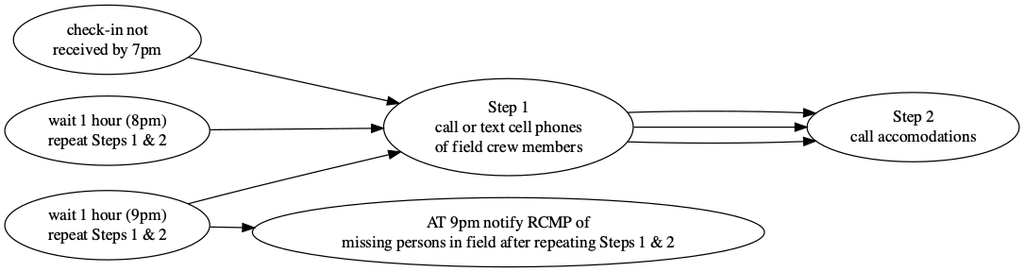

Table 2: Potential sample locations.

| id | Stream | long | lat | comments |
| --- | --- | --- | --- | --- |
| 3054 | Johnny David Creek | -126.4478 | 54.59474 | Sampling could provide insight into how high salmon acsend in this watershed. |
| 8414 | Clore | -128.0377 | 54.43099 | Modelled 11% gradient upstream for 500m. close to Clore River so potential high values. |
| 8454 | Trib to Copper | -127.8154 | 54.80895 | BT and DV confirmed. Two SFC priority sites upstream too. |
| 8455 | Trib to Copper | -127.8114 | 54.81153 | SFC ranked as high priority. BT and DV confirmed. |
| 8465 | Trib to Copper | -127.7293 | 54.82940 | Fish captured downstream. Smaller potential habitat gain. |
| 8478 | Trib to Copper | -127.5999 | 54.76787 | DV known kupstream at cascade. Small steeper habitat. |
| 8511 | Trib to Copper | -127.5744 | 54.82840 | Small watershed. Close to larger stream with salmon though so may have some decent hab values. |
| 8518 | Trib to Copper | -127.3677 | 54.76332 | Fish sampling already conducted but habitat confirmation may be helpful. |
| 8525 | Trib to Copper | -127.7396 | 54.81270 | Smaller stream with DV upstream. Outlet drop. |
| 8527 | Trib to Copper | -127.7213 | 54.80815 | DV confirmed upstream and SFC report indicates large outlet drop. Smaller stream though. |
| 8530 | Trib to Copper | -127.7129 | 54.80518 | Duplicate. Matched to wrong modelled crossing so corrected in bcfishpass. |
| 8532 | Trib to Copper | -127.7007 | 54.81185 | Habitat confirmation would be helpful. Fish confirmed here. |
| 8543 | Trib to Copper | -127.5671 | 54.78977 | Just slightly highe than steelhead model criteria. Close to McDonell Lake with fish upstream |
| 8545 | Trib to Copper | -127.6451 | 54.79016 | RB confirmed upstream. SFC recomends habitat assessment |
| 8547 | Trib to Copper | -127.6004 | 54.79309 | CT (and potentially RB) confirmed. Small lake mapped upstream. |
| 8742 | – | -127.3084 | 54.04645 | Remediated |
| 57793 | Vallee Creek | -126.8141 | 54.52438 | – |
| 57978 | Tributary to Trout Creek | -127.4822 | 54.93291 | – |
| 58067 | Tributary to Gramophone Creek | -127.2858 | 54.97087 | – |
| 58159 | McDowell Creek | -127.0204 | 54.67521 | Restoration likely forthcoming so sampling could inform monitoring program. |
| 58242 | Kathlyn Creek | -127.1811 | 54.79231 | – |
| 123377 | Thompson Creek | -126.8090 | 54.57223 | Would be good to get baseline conditions for species composition and abundance. |
| 123392 | Lemieux Creek | -126.8540 | 54.62160 | – |
| 123393 | Lemieux Creek | -126.8549 | 54.62081 | – |
| 123426 | Robin Creek | -126.8782 | 54.63903 | – |
| 123697 | Tributary to Driftwood Creek | -126.9875 | 54.85582 | – |
| 123699 | Tributary to Driftwood Creek | -127.0021 | 54.84796 | – |
| 123794 | Tributary to Blunt Creek | -127.1806 | 55.09398 | Sampling would provide insight into salmon use but unliley to have time. |
| 123795 | Tributary to Blunt Creek | -127.1855 | 55.09473 | Sampling could provide insight into salmon use but time limited so unlikely to happen this year. |
| 124500 | Helps Creek | -127.0228 | 54.65954 | Species compositionupstream and downstream could be insighful for prioritization and baseline if Telkwa Coal helps move this one ahead. |

[output cut: 116 more lines]

# References

Fish Passage Technical Working Group. 2011. “A Checklist for Fish Habitat Confirmation Prior to the Rehabilitation Fo a Stream Crossing.” https://www2.gov.bc.ca/assets/gov/environment/natural-resource-stewardship/land-based-investment/forests-for-tomorrow/checklist-for-fish-habitat-confirmation-201112.pdf.

McPhail, J. D., and R Carveth. 1993. “Field Key to the Freshwater Fishes of British Columbia.” https://www2.gov.bc.ca/assets/gov/environment/natural-resource-stewardship/nr-laws-policy/risc/field_key_to_freshwater_fishes_of_bc_field_size_water_resistant_version.pdf.

MoE. 2011. “Field Assessment for Determining Fish Passage Status of Closed Bottom Structures.” BC Ministry of Environment (MoE). https://www2.gov.bc.ca/assets/gov/environment/natural-resource-stewardship/land-based-investment/forests-for-tomorrow/field-assessment-for-determining-fish-passage-status-of-cbs.pdf.